# Coursework Report

*N* removed NAs: 2

*N* removed typo: 1

*N* removed <18: 25

*N* total clean: 122

| Group | *N* | *M*<sub>age</sub> | *M*<sub>rating</sub> |
| --- | --- | --- | --- |
| Control | 65 | 20.4 | 6.04 |
| Experim | 57 | 20.5 | 5.23 |

**Main analysis results**

*t*(120) = 5.54, *p* < .001

[interactive chart not shown]

[figure not shown]

[interactive chart not shown]

# Coursework Report

Analysing Data, Spring 2020

# Methods

## Participants

Initially, 150 participants took part in the study however 28 participants results were removed from the study due to being under the age of 18 or reporting improbable ages, leaving the final number of participants whose data was included in the results to a total of 122. The participants in the study ranged from the age of 18 - 26 and a mean age of 20.44 years old with a standard deviation of 1.98. Table 1 shows the number of participants in each condition.

Table 1 - Summary of Participant in Experimental Condition

| Condition | Number of Participants | Percentage |
| --- | --- | --- |
| control | 65 | 53.3 |
| experimental | 57 | 46.7 |

## Design

The conceptual hypothesis for this experiment is that the colour red increases women’s attraction to men and does so by increasing the perception women have of the man’s status, enhancing attraction. The independent variable for this study was the colour, either red or white, boarded around the 4-inch x 6-inch picture of the head and upper torso of a ‘moderately attractive young man’, selected from a standard photo set (Corneille, Monin, & Pleyers, 2005). The dependent variable for the study was the women’s perceived attractiveness, this was measured using 3 face-valid questions in which the participants answered using a 9-point scale ranging from 1 (not at all attractive) to 9 (extremely attractive). The questions in which the participants were asked to answer in order to measure perceived attractiveness consisted of: “How attractive do you think this person is?”, “How pleasant is this person to look at?” and “If I were to meet them person in this picture face to face, I would think he is attractive.”

The operational hypothesis for this experiment was that ratings of women’s perceived attractiveness for men will be significantly higher when the man is shown alongside the colour red than with the colour white. In order to test the significance of this, a statistical t-test will be done on the results of the study.

# Results

The results of this experiment show that the mean responses from the participants were higher in the control condition, where the participants saw the picture with a white background, than the experimental condition, with the red background. This is shown in Table 2 below with the mean response and the standard deviation for each question.

Table 2 - Summary of Participant Responses

| Condition | Number of Participants | Percentage | Mean response Q1 | Standard Diviation Q1 | Mean response Q2 | Standard Diviation Q2 | Mean response Q3 | Standard Diviation Q3 |
| --- | --- | --- | --- | --- | --- | --- | --- | --- |
| control | 65 | 53.3 | 6.02 | 1.23 | 6.22 | 1.24 | 5.89 | 1.46 |
| experimental | 57 | 46.7 | 4.96 | 1.48 | 5.35 | 1.32 | 5.37 | 1.22 |

Figure 1 shows the mean of each condition combined to give one value for the responses of the participants in each condition.

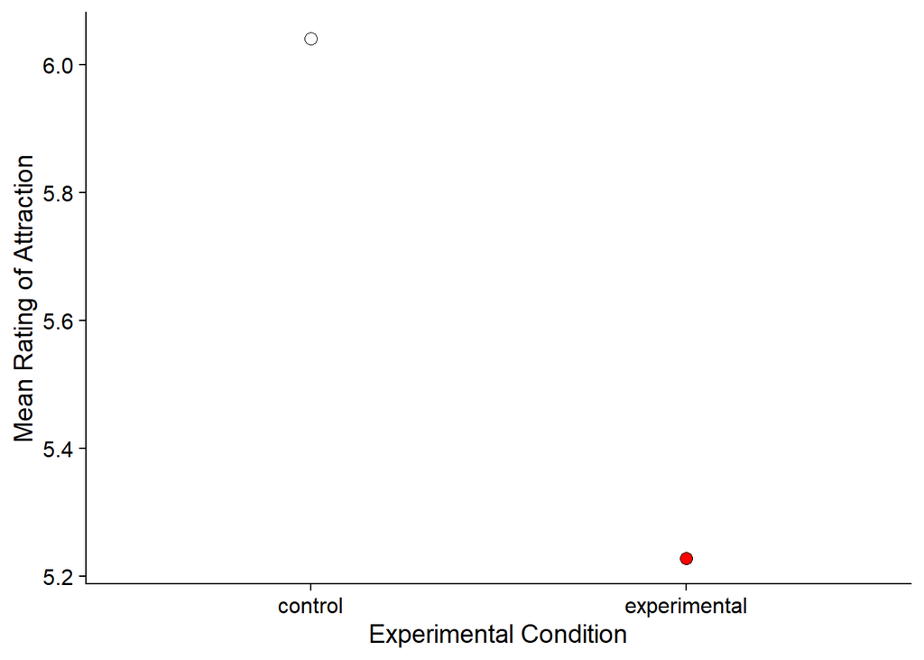

Figure 1 - Summary of Participant Responses

The graph shows that the mean response for participants in the control condition was 6.04 with a standard deviation of 0.76 whereas the mean response for participants in the experimental condition was 5.23 with a standard deviation of 0.86. This shows that the range of responses in the experimental condition was larger than in the control condition, meaning there was more of a variety of responses in the experimental condition.

A statistical t-test was complete on the results from the study which showed that there was a significant difference in mean attractiveness ratings for the control vs experimental conditions (Mean difference = 0.81, 95% CI [0.52, 1.1], t(120) = 5.54), p < .001).

# Discussion

The results of this experiment show that the mean response of perceived attractiveness from participants were higher in the control condition, where the participants saw the picture of the man with a white background, than the experimental condition, where the participants saw the picture of the man with a red background. This means that the results support the opposite of the predicted hypothesis and, instead, showed that there were significantly lower ratings of attraction given by women to men shown with a red background than there is to men shown with a white background. This differs from the results of Elliot et al’s 2010 study which alternatively found that participants in the experimental condition, compared to those in the control condition, had a significantly higher rating of attractiveness thus supporting the alternative hypothesis and ‘suggesting that colour influences participants’ ratings without their awareness’ (Elliot et al., 2010). One factor which may have influenced the variation in results between this replication study and the original study are the participants used. In Elliot et al’s original study 21 undergraduates in the United States participated whereas in this replication study 122 participants were involved; this is a bigger sample and therefore the results may be more valid and generalisable to a wider population than the results from the original study. On the other hand, the participants in the original study ranged from 18 – 25, similarly the participants in this replication study ranged from 18 – 26, thus the results should both be generalisable to similar age ranges and therefore, if this is not the cause of the variation of results, another factor which may have influenced the variation in the results could have been the ethnicity of the participants. Elliot et al’s experiment took place in an American university whereas this replication of the experiment took place in an English university and this difference in culture may account for the variation in the results between the two.

Although the results from this replication experiment did not support the original study’s findings, it has been said by Gregory Francis 2013, that ‘either some experiments with null findings were not reported or the reported experiments were run improperly in a way that inflated the likelihood of rejecting the null hypothesis’, he then went on to say that ‘because of the presence of publication bias, the findings in Elliot et al (2010) should be considered non-scientific’. This suggests that the results of Elliot et al’s 2010 study that were reported may not be correct, this is supported by another replication study which found that ‘despite having tested a larger sample of participants, there was no significant effect of colour condition on perceived attractiveness’ (Hesslinger, V.M., Goldbach, L. and Carbon, C., 2015).

One strength of this replication study is that the man shown in the photos was the same man in each condition, this allowed a direct comparison to be made between the two photos with only the colour being manipulated as a factor which could influence the perceived and reported attractiveness. One other strength is the method used to collect the ratings of attractiveness. For each of the three questions asked to the participants a Likert scale of nine options was given, ranging from not at all attractive to extremely attractive. Having nine points on the scale allows for the participants to give a more valid rating of perceived attractiveness and therefore increasing the internal validity of the results. On the other hand, one limitation of this replication study is the sample of participants used. Only 122 women within the age range of 18-26 took part in the experiment, this lowers the generalisability of the results as the sample size is unlikely to be big enough to be representative of the whole target population and because of the sample’s age range being between 18-26 and the gender only being women, it can therefore not be generalised to other age groups or genders.

As the results of this replication study found that white significantly increased perceived attractiveness compared to red, this could inspire future research to investigate the effects other colours have on attractiveness. This can be done by replicating the methods of this experiment but with multiple different colours being shown as a background to the picture of a ‘moderately attractive young man’, followed by women reporting their perceived attractiveness to the man. In addition to this, as the replication experiment used a ‘picture of the head and upper torso of a moderately attractive young man’, the results for perceived attractiveness of the man can therefore only be generalised to moderately attractive young men, however for other levels of attractiveness, colour could have a different effect. This could be investigated by conducting this experiment three times, one with a man of ‘low attractiveness’, one with a man of ‘moderate attractiveness’ and one with a man of ‘high attractiveness’, the results could then be compared to see if white still increased the perceived attractiveness ratings of the man by the same proportion or if there colour has a higher effect depending on the level of the man’s attractiveness.

To conclude, the results found from this experiment, which show that perceived attractiveness is significantly higher for men shown alongside the colour white than the colour red, do not collate with the results from Elliot et al’s 2010 original study, however this could be due to the differences in participants used or according to Gregory Francis (2013) due to publication bias within the original study. There are strengths within this study such as using the same picture for all conditions and a large point Likert scale to measure the dependent variable of perceived attractiveness to increase internal validity of the results but there are also some weaknesses of the study such as having a small sample size with a small age range, lowing the generalisability of the findings. The results, nevertheless, do guide suggestions for further research such as looking into the effects of other colours on perceived attractiveness, effects of colours on perceived attractiveness for different genders and effects of colours on perceived attractiveness on people of different levels of attractiveness.

# References

Hesslinger, V. M., Goldbach, L., & Carbon, C.-C. (2015). Men in red: A reexamination of the red-attractiveness effect. Psychonomic Bulletin & Review, 22(4), 1142–1148. https://doi.org/10.3758/s13423-015-0866-8

Publication bias in “Red, rank, and romance in women viewing men,” by Elliot et al. (2010)—ProQuest. (n.d.). Retrieved 25 April 2020, from https://search.proquest.com/docview/1285624492?accountid=14182

Red, rank, and romance in women viewing men—ProQuest. (n.d.). Retrieved 1 April 2020, from https://search.proquest.com/docview/745195146?accountid=14182#s5

The red-attractiveness effect, applying the Ioannidis and Trikalinos (2007b) test, and the broader scientific context: A reply to Francis (2013) - ProQuest. (n.d.). Retrieved 24 April 2020, from https://search.proquest.com/docview/1285624501?accountid=14182